# Prediction Assignment Writeup

Blaž Zupančič

24 9 2019

## Introduction

Using data from Velloso, E.; Bulling, A.; Gellersen, H.; Ugulino, W.; Fuks, H. Qualitative Activity Recognition of Weight Lifting Exercises, we build a predition model to evaluate if participants were doing any and which of the common mistakes while exercising using weights.

In order to evaluate the correctness of weight lifting, 4 sensors (belt, glove, arm-bend and dumbell) with xyz orientation recordings were used. From the article by the authors: “Participants were asked to perform one set of 10 repetitions of the Unilateral Dumbbell Biceps Curl in five different fashions: exactly according to the specification (Class A), throwing the elbows to the front (Class B), lifting the dumbbellonly halfway (Class C), lowering the dumbbell only halfway(Class D) and throwing the hips to the front (Class E). Class A corresponds to the specified execution of the exercise, while the other 4 classes correspond to common mistakes”

## Data subsetting

```r
training <- read.csv("./pml-training.csv")
testing <- read.csv("./pml-testing.csv")

training <- training[,-c(1:7)]
testing <- testing[, -c(1:7)]

col_all_NA <- which(sapply(testing, FUN = function(x) all(is.na(x))))

n_col <- length(col_all_NA)

testing <- testing[, -col_all_NA]
training <- training[, -col_all_NA]

ncol(training)
```

```
## [1] 53
```

```r
ncol(testing)
```

```
## [1] 53
```

```r
inTrain = createDataPartition(training$classe, p = 3/4)[[1]]

validation = training[-inTrain,]
training = training[ inTrain,]
```

Looking at the data we can see that the first 7 columns are providing information about the experiments and are not features of classe. Therefor we subset them from the dataset. Another thing we see is that 100 columns of the test dataset include only NAs. Both the training and the test dataset were subset not to include these columns. In order to use a suitable method we turned to https://mlr.mlr-org.com/articles/tutorial/filter_methods.html#current-methods, where we found R package randomForestSRC by Hemant Ishwaran and Udaya B. Kogalur, which can be used to make classification models and is quite fast.

## Analysis

### Model building

```r
model <- rfsrc(classe ~ ., data = training)

print(model)
```

```
##                          Sample size: 14718
##            Frequency of class labels: 4185, 2848, 2567, 2412, 2706
##                      Number of trees: 1000
##            Forest terminal node size: 1
##        Average no. of terminal nodes: 930.797
## No. of variables tried at each split: 8
##               Total no. of variables: 52
##        Resampling used to grow trees: swor
##     Resample size used to grow trees: 9302
##                             Analysis: RF-C
##                               Family: class
##                       Splitting rule: gini *random*
##        Number of random split points: 10
##               Normalized brier score: 4.39
##                                  AUC: 99.99
##                           Error rate: 0.01, 0, 0, 0.01, 0.01, 0
##
## Confusion matrix:
##
##           predicted
##   observed    A    B    C    D    E class.error
##          A 4178    6    0    0    1      0.0017
##          B    7 2837    4    0    0      0.0039
##          C    0   15 2549    3    0      0.0070
##          D    0    0   25 2383    4      0.0120
##          E    0    0    1    9 2696      0.0037
##
##  Overall error rate: 0.5%
```

```r
model_test_err <- round(get.mv.error(model) * 100, 2)

model_time <- system.time(rfsrc(classe ~ ., data = training))[3]
```

The complete analysis using randomForestSRC with default settings took a moderate 48 s. Looking at the paper from the authors, we noticed they cut down the number of variables they eventually used in the random forest model with Correlation-based Feature Subset Selection for Machine Learning by M. A. Hall. As rfsrc method is reasonably fast we felt no need to do the same.

### Model validation

```r
cross_val <- predict(model, newdata = validation)

confusionMatrix(cross_val$yvar, validation$classe)
```

```
## Confusion Matrix and Statistics
##
##           Reference
## Prediction    A    B    C    D    E
##          A 1395    0    0    0    0
##          B    0  949    0    0    0
##          C    0    0  855    0    0
##          D    0    0    0  804    0
##          E    0    0    0    0  901
##
## Overall Statistics
##
##                Accuracy : 1
##                  95% CI : (0.9992, 1)
##     No Information Rate : 0.2845
##     P-Value [Acc > NIR] : < 2.2e-16
##
##                   Kappa : 1
##
##  Mcnemar's Test P-Value : NA
##
## Statistics by Class:
##
##                      Class: A Class: B Class: C Class: D Class: E
## Sensitivity            1.0000   1.0000   1.0000   1.0000   1.0000
## Specificity            1.0000   1.0000   1.0000   1.0000   1.0000
## Pos Pred Value         1.0000   1.0000   1.0000   1.0000   1.0000
## Neg Pred Value         1.0000   1.0000   1.0000   1.0000   1.0000
## Prevalence             0.2845   0.1935   0.1743   0.1639   0.1837
## Detection Rate         0.2845   0.1935   0.1743   0.1639   0.1837
## Detection Prevalence   0.2845   0.1935   0.1743   0.1639   0.1837
## Balanced Accuracy      1.0000   1.0000   1.0000   1.0000   1.0000
```

We used the package’s in-build out of sample error rate calculation. On the validation subset our results were very close to being perfect. This result makes us doubt in our model since it seems too good to be true. There is a possibility we still have variables that are inherent to the experiments themselves (like names or time signatures), not of the mistakes in doing the exercises.

### Prediction for testing problems

```r
result <- predict.rfsrc(model, testing)

test_classe_names <- names(data.frame(result$predicted))

test_class_no <- apply(result$predicted, MARGIN = 1, function(x) which(x == max(x)))

test_classe <- test_classe_names[test_class_no]

table <- t(data.frame(test_classe))

colnames(table) <- testing$problem_id

knitr::kable(table, align = "c", caption = "Predicted classe for testing problems")
```

Predicted classe for testing problems

|  | 1 | 2 | 3 | 4 | 5 | 6 | 7 | 8 | 9 | 10 | 11 | 12 | 13 | 14 | 15 | 16 | 17 | 18 | 19 | 20 |
| --- | --- | --- | --- | --- | --- | --- | --- | --- | --- | --- | --- | --- | --- | --- | --- | --- | --- | --- | --- | --- |
| test_classe | B | A | B | A | A | E | D | B | A | A | B | C | B | A | E | E | A | B | B | B |

## Appendix

List of low variance variables:

```r
low_val <- nearZeroVar(training)

print(names(training)[low_val])
```

```
## character(0)
```

Correlation matrix of the ramaining variables.

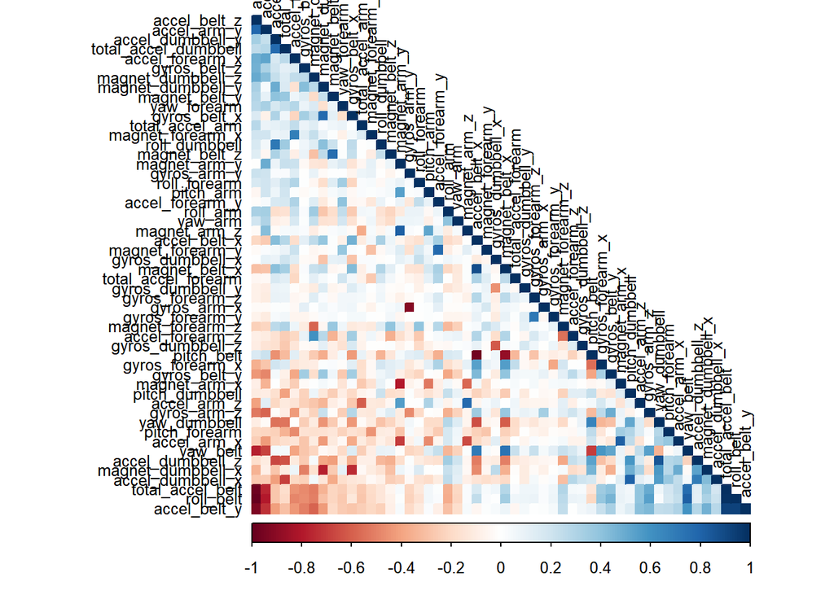

```r
corMatrix <- cor(training[, -c(low_val, ncol(training))])
corrplot(corMatrix, order = "FPC", method = "color", type = "lower",
         tl.cex = 0.8, tl.col = rgb(0, 0, 0), )
```